# Método

Said E. Jiménez

6 de marzo de 2019

## Análisis descriptivo de datos

Se obtuvieron las proporciones de las decisiones pagar o no pagar la mitad, así como las promesas realizadas, posteriormente se calcularon las variaciones en las proporciones de acuerdo a los compañeros de juego y la condición de presencia o ausencia de promesas.

## Modelamiento Bayesiano

### Modelo Jerárquico

Se utilizó inferencia bayesiana para evaluar el efecto de las condiciones experimentales en la tasa de pago a nivel individual y poblacional. Para tal propósito se realizó un modelo jerárquico que asume que la incertidumbre en el efecto de promesas y parejas sobre la conducta de cada individuo proviene de distribuciones poblacionales comunes para los parámetros del modelo:

$$\begin{aligned}
&y_i \sim \mathrm{Bernoulli}(\theta_i) \\
&\mathrm{logit(\theta_i)} = \mathbf{X}\beta + \mathbf{Z}u
\end{aligned}$$
En el modelo anterior, cada decisión $y_i$ proviene de una distribución Bernoulli con probabilidad de pagar $\theta_i$, el objetivo del modelo jerárquico es predecir cada decisión a través la combinación lineal de los predictores transformados por su función ligadora inversa $\mathrm{logit}$. En el modelo anterior, $\beta$ y $u$ son coeficientes a nivel poblacional y nivel individual respectivamente, mientras que $\mathbf{X}$, $\mathbf{Z}$ son sus correpondientes matrices del diseño.

El modelo estima que la probabilidad $\theta_i$ de que en cada ensayo se decida pagar la mitad está en función del efecto de la presencia de promesas $\beta^{promise}$, así como de los compañeros con cercanía social baja $\beta^{confederate}$ y alta $\beta^{friend}$. También asume que pueden existir diferencias individuales en el desempeño durante la tarea, las cuales son captadas por los parámetros $u$ y constituyen ajustes a los coeficientes poblacionales. Cabe remarcar que el modelo evalúa explícitamente la incertidumbre respecto a $u$, lo cual es una ventaja con relación a los modelos que asumen que $u$ es parte del término de error.

El modelo se programó en R por medio del paquete **brms**, que realiza la inferencia mediante el muestreo por Markov chain Monte Carlo a través de **Stan**. Las distribuciones posteriores de todos los parámetros fueron aproximadas con cuatro cadenas de 2000 iteraciones cada una, las primeras 1000 iteraciones de cada cadena fueron descartadas (periodo de calentamiento), para un total de 4000 muestras post-calentamiento. La convergencia del modelo fue evaluada a través de la inspección visual de las cadenas y el cálculo del estadístico $\hat{R}$, que para todos los parámetros fue de 1, lo que se interpreta como convergencia.

### Modelamiento de mezclas latentes

Asume que las decisiones de los individuos podrían provenir de una combinación (o *mezcla*) de procesos psicológicos no observables (*latentes*), el rasgo latente más importante en este experimento es la (des)honestidad. Se modelaron las diferencias en las tasas de pago entre participantes como una combinación de $N$ distribuciones de subpoblaciones. El modelo asumió que las tasas de pago provenían de una o dos mezclas de distribuciones, o grupos latentes.

El modelo de una mezcla, asumía que cada decisión $d_{i,j}$ de cada sujeto provenía de una distribución Bernoulli con probabilidad $\theta_{i,j}$. Asimismo que $\theta_{i,j}$ provenía de una distribución jerárquica Beta con parámetros $\alpha$ y $\beta$. La distribución Beta fue reparametrizada en términos de media $\mu$ y precisión $\lambda$, ya que $\mu = \alpha/(\alpha + \beta)$ y $\lambda = \alpha + \beta$.

$$\begin{aligned}
&\mu \sim \mathrm{Uniform}(0, 1)\\
&\lambda \sim \mathrm{Uniform}(4, 100)\\
&\theta_{i,j} \sim \mathrm{Beta}(\mu\lambda, (1 - \mu)\lambda)\\
&d_{i,j} \sim \mathrm{Bernoulli}(\theta_{i,j})
\end{aligned}$$

El modelo de dos mezclas es aproximadamente igual al anterior, sin embargo ahora asume que las decisiones provienen de una *mezcla* de las distribuciones de dos grupos, una distribución Beta con parámetros $\mu_1\lambda_1$ y $(1 - \mu_1) \lambda_1$ y otra con párametros $\mu_2\lambda_2$ y $(1 - \mu_2) \lambda_2$, el parámetro $z_i$ determina la probabilidad de que cada sujeto pertenezca a uno de dos grupos latentes, se distribuye Bernoulli con probabilidad $\phi$, que a su vez sigue una distribución inicial Beta relativamente poco informativa.

$$\begin{aligned}
&\mu_1 \sim \mathrm{Uniform}(0, 1)\\
&\mu_2 \sim \mathrm{Uniform}(\mu_1, 1)\\
&\lambda_{1:2} \sim \mathrm{Uniform}(4, 100)\\
&z_i \sim \mathrm{Bernoulli}(\phi)\\
&\theta_{i,j} \sim \Bigg\{
\begin{array} {lr}
\mathrm{Beta}(\mu_1\lambda_1, (1 - \mu_1)\lambda_1) & \mbox{if} & z_i = 0 \\
\mathrm{Beta}(\mu_2\lambda_2, (1 - \mu_2)\lambda_2) & \mbox{if} & z_i = 1
\end{array} \\
&d_{i,j} \sim \mathrm{Bernoulli}(\theta_{i,j})\\
&\phi \sim \mathrm{Beta}(5, 5)
\end{aligned}$$

Los modelos de 1 y 2 mezclas, se programaron en R mediante el paquete **rjags**, que realiza la inferencia mediante el muestreo por Markov chain Monte Carlo a través de **JAGS**. Las distribuciones posteriores de todos los parámetros fueron aproximadas con tres cadenas de 26000 iteraciones cada una, se descartaron las primeras 6000 de cada cadena como periodo de calentamiento, para un total de 60000 muestras post-calentamiento. La convergencia del modelo fue evaluada a través de la inspección visual de las cadenas y el cálculo del estadístico $\hat{R}$, que varió de 1 a 1.05 para todos los parámetros lo que indica convergencia.

### Modelamiento de los tiempos de reacción

Un hallazgo constante en la investigación sobre engaño y deshonestidad, es la diferencia en los tiempos de reacción entre quienes toman decisiones *deshonestas* vs. decisiones *honestas*, en general, se han encontrado latencias breves en personas *deshonestas* en comparación con las de las personas *honestas*.

Se estimaron las medias poblacionales del grupo de deshonestos y honestos mediante un modelo bayesiano jerárquico que asumía que el tiempo de reacción proviene de una distribución $rt_i \sim \mathrm{Half-Normal}(0, 5)$ (dado que no puede haber tiempos de reacción negativos), con parámetros $\mu_{Dishonest}$ y $\mu_{Honest}$ y desviación estándar común $\sigma$.

Asimismo, se modeló la variabilidad intrasujeto en los tiempos de reacción por medio de interceptos variantes por participante. El modelo se ajustó en R por medio de **brms** y **Stan** en condiciones iguales a las descritas anteriormente y con resultados adecuados de convergencia para todos los parámetros, $\hat{R} = 1$.

### Contraste de hipótesis

Para los modelos de la tasa de pago y tiempo de reacción se utilizó el factor de Bayes por medio del método de Savage-Dickey, que calcula la razón de la densidad de la distribución posterior sobre la densidad de la distribución inicial de algún parámetro en el punto de interés. Específicamente para el modelo de la tasa de pago, se evaluó la hipótesis de si las promesas tendrían un efecto positivo en las tasas de pago ($H_1: \beta^{promise} > 0$), así como si la cercanía social alta (amigo) tendría mayores tasas de pago que la cercanía social baja (confederado) ($H_1: \beta^{friend} - \beta^{confederate} > 0$). Para el modelo del tiempo de reacción, la hipótesis fue si los *deshonestos* tendrían tiempos breves en comparación con los *honestos* ($H_1: \mu_{Dishonest} - \mu_{Honest} < 0$).

### Comparación de modelos

Los modelos de una y dos mezclas se compararon por medio del criterio de información DIC (deviance information criteria), en el que los puntajes bajos indican mejores modelos. La estimación de la diferencia entre el modelo de 1 y 2 mezclas favorece al modelo de dos mezclas ($\mathrm{Difference}= 1.21$, $\mathrm{SE}= 3.49$).

## Resultados

### Descriptivos

Se muestra en la figura 1, la frecuencia de veces en que los participantes pagaron la mitad, así como la frecuencia de promesas que fueron seleccionadas. En la figura 2, se muestra la proporción de pagos realizados dependiendo de cada pareja y de la condición de promesas.

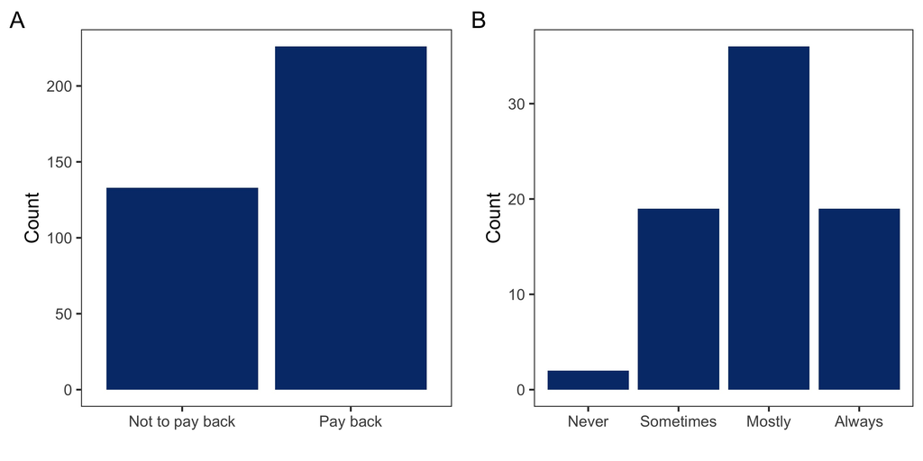

Fig. 1 Frecuencies of paying and Promise choice

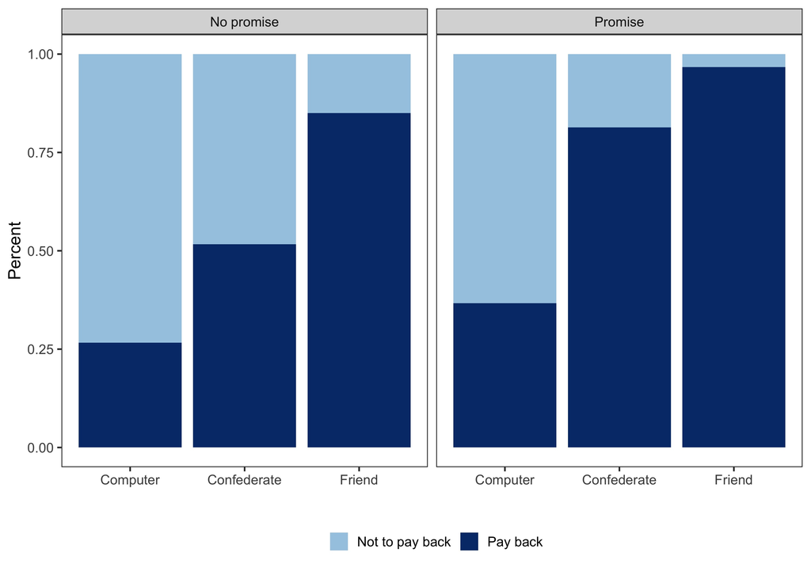

Fig. 2 Rates by partners and promise condition

### Resultados: modelo jerárquico

En la tabla 1, se muestran los efectos poblacionales del modelo bayesiano jerárquico para la tasa de pago. Se presentan las estimaciones de cada coeficiente del modelo en escala *logit*, su error estándar y los intervalos de credibilidad bayesianos del 95%. Los cuales indican los límites inferiores y superiores de las estimaciones entre los que se ubica el 95 % de probabilidad.

Table 1. Population-Level Effects of Task

| Term | Estimate | SE | L-95% CI | U-95% CI |
| --- | --- | --- | --- | --- |
| $\beta^0$ | -1.62 | 0.40 | -2.31 | -1.02 |
| $\beta^{promise}$ | 1.27 | 0.40 | 0.64 | 1.92 |
| $\beta^{confederate}$ | 2.01 | 0.55 | 1.20 | 2.97 |
| $\beta^{friend}$ | 4.15 | 0.77 | 3.07 | 5.49 |

La figura 3A muestra la incertidumbre con respecto a la estimación de los coeficientes, la linea central indica la mediana de la distribución y el área sombreada el intervalo del 50 % de probabilidad. Para visualizar el efecto conjunto de las condiciones experimentales en la probabilidad de pagar la mitad, se realizó su combinación lineal para obtener un sólo predictor ($\mathrm{linpred_i}$), se le aplicó la función ligadora inversa *logit* y se transformó su output en probabilidades por medio de la función logistica $1 / (1 + \exp(-\mathrm{linpred}_i))$.

La figura 3B muestra la probabilidad de pagar la mitad, como función de la combinación lineal de las condiciones experimentales, las lineas delgadas muestran la incertidumbre en la predicción con una muestra aleatoria de tamaño 100 de las distribuciones posteriores de los parámetros poblacionales. La linea gruesa representa la media de las distribuciones posteriores de los parámetros poblacionales.

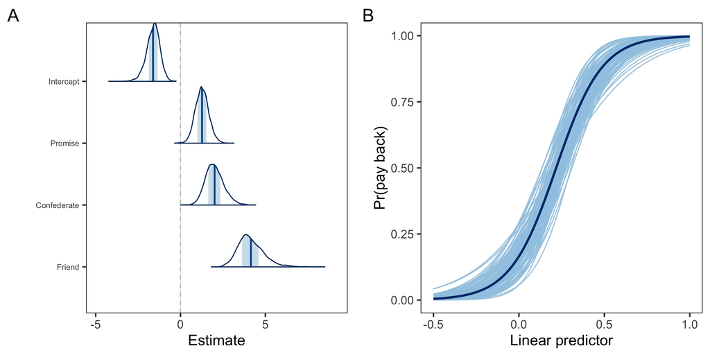

Fig. 3 Estimates with uncertainty and linear predictor

En un procedimiento similar al descrito para la figura 3B, la figura 4 representa el efecto conjunto de las condiciones experimentales en la probabilidad de pagar la mitad para cada sujeto. Ya que el modelo jerárquico asume que las diferencias individuales se pueden modelar realizando un ajuste $u$ a los coeficientes poblacionales $\beta$, se obtuvieron 50 muestras aleatorias de las distribuciones posteriores de los parámetros $u$ para cada sujeto, se realizó el ajuste al modelo poblacional y se presenta en lineas delgadas la incertidumbre en la predicción individual.

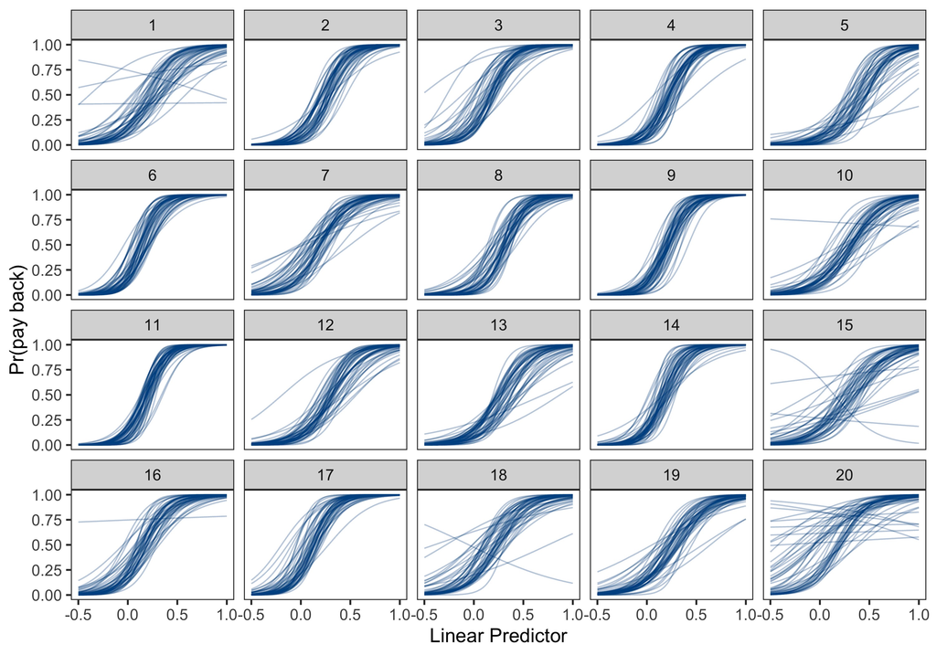

Fig. 4 Estimates with uncertainty by subject